# Analyse

2024-11-14

```r
#Charger les données :
library(carData)
BDD <- TitanicSurvival
```

Présentation des données : Le data frame “BDD” contient 1309 observations avec 4 variables :

1- survived : survie du passager (yes ou no), variable catégorielle binaire.

2- sex : sexe du passager (female ou male), variable catégorielle nominale.

3- age : âge en années (avec 263 valeurs manquantes), variable numérique continue.

4- passengerClass : classe du billet (1st, 2nd, 3rd), variable catégorielle ordinale.

```r
#Présentez les statistiques descriptives
summary(BDD)
```

```
##  survived      sex           age          passengerClass
##  no :809   female:466   Min.   : 0.1667   1st:323
##  yes:500   male  :843   1st Qu.:21.0000   2nd:277
##                         Median :28.0000   3rd:709
##                         Mean   :29.8811
##                         3rd Qu.:39.0000
##                         Max.   :80.0000
##                         NA's   :263
```

#Graphique pour la répartition des survivants en fonction du sexe avec des couleurs personnalisées

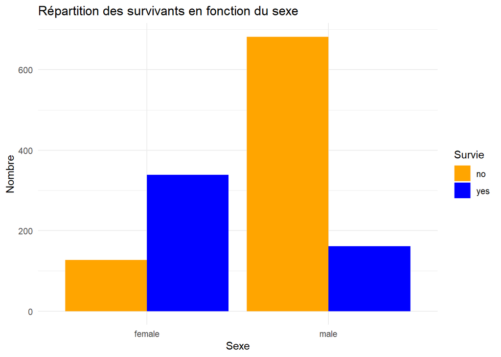

```r
library(ggplot2)
ggplot(BDD, aes(x = sex, fill = survived)) +
  geom_bar(position = "dodge") +
  labs(title = "Répartition des survivants en fonction du sexe",
       x = "Sexe",
       y = "Nombre",
       fill = "Survie") +
  scale_fill_manual(values = c("orange", "blue")) +
  theme_minimal()
```

Interprétation : Le graphique montre que le nombre de non-survivants (en orange) est supérieur chez les hommes par rapport aux femmes. À l’inverse, le nombre de survivants (en bleu) est nettement plus élevé chez les femmes, soulignant une différence significative entre les sexes en termes de survie.

#Graphique : Répartition des survivants en fonction de la classe

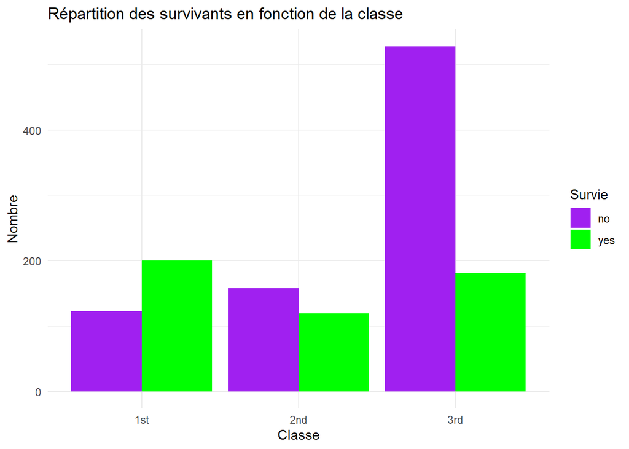

```r
ggplot(BDD, aes(x = passengerClass, fill = survived)) +
  geom_bar(position = "dodge") +
  labs(title = "Répartition des survivants en fonction de la classe",
       x = "Classe",
       y = "Nombre",
       fill = "Survie") +
   scale_fill_manual(values = c("purple", "green")) +
  theme_minimal()
```

#Représentation de l’age en fonction de la variable survived.

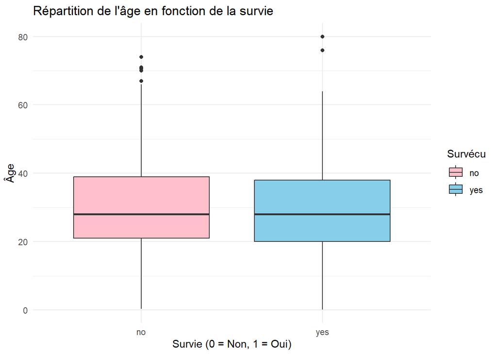

```r
ggplot(BDD, aes(x = as.factor(survived), y = age, fill = as.factor(survived))) +
  geom_boxplot() +
  labs(title = "Répartition de l'âge en fonction de la survie",
       x = "Survie (0 = Non, 1 = Oui)",
       y = "Âge",
       fill = "Survécu") +
  scale_fill_manual(values = c("pink", "skyblue")) +
  theme_minimal()
```

Interprétation : Le graphique montre la répartition des survivants et des non-survivants selon l’âge, sans différence significative entre les groupes.

# Chargement du package “TitanicPckg”

```r
library(TitanicPckg)

taux_survie_class(BDD)
```

```
## # A tibble: 3 × 2
##   passengerClass TauxSurvie
##   <fct>               <dbl>
## 1 1st                 0.619
## 2 2nd                 0.430
## 3 3rd                 0.255
```

```r
taux_survie_sex(BDD)
```

```
## # A tibble: 2 × 2
##   sex    TauxSurvie
##   <fct>       <dbl>
## 1 female      0.727
## 2 male        0.191
```